# An insight into Mohamed Salah

Predicting Salah’s G/A Contribution

Borno Siddiqui

Spring term 2025

## An insight into Mohamed Salah

Mohamed Salah is currently a 32 year old footballer who arguably should be past his prime by now but with the current numbers he is putting up, one can only assume that he will only get better. This project will give us an insight to not only Salah’s past G/A (goals and assists) but will also predict how well he will do in the near future.

## Visualising Salah’s G/A Per Season

In this section, we will see Salah’s G/A per year and get an idea of how he has been doing since 2014. Note that the dates do not represent the actual calender year but each English Premier League season, for e.g. the date 2020 represents the season 20/21.

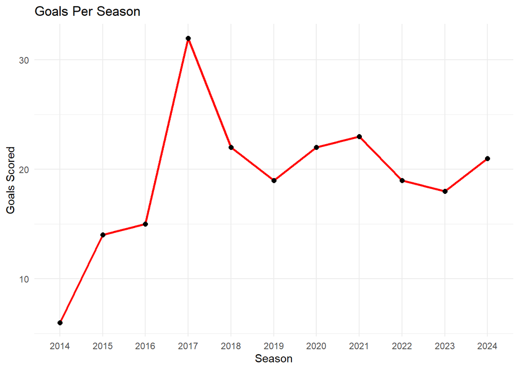

```r
goals_per_season <- stats %>%
  group_by(season) %>%
  summarise(goals = sum(goals))
# aggregate goals per season

goals_per_season$season <- as.factor(goals_per_season$season) # converting season to date format

ggplot(goals_per_season, aes(x = season, y = goals, group = 1)) +
  geom_line(color = "red", linewidth = 1) +
  geom_point(color = "black", size = 2) +
  labs(title = "Goals Per Season", x = "Season", y = "Goals Scored") +
  theme_minimal() # plotting goals per year/season
```

From 2018, we can see Salah has been very consistent reach a goal tally of around 20 per season.

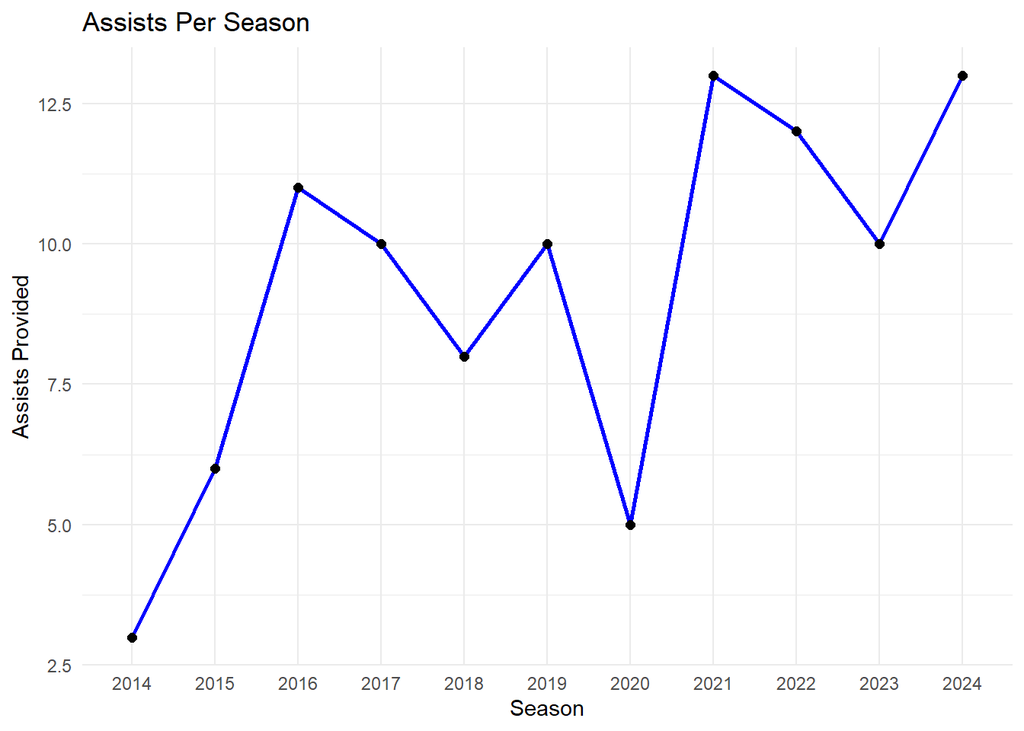

```r
# similar code as above
assists_per_season <- aggregate(assists ~ season, data = stats, sum)

assists_per_season$season <- as.factor(assists_per_season$season)

# plotting the assists graph
ggplot(assists_per_season, aes(x = season, y = assists, group = 1)) +
  geom_line(color = "blue", size = 1) +
  geom_point(color = "black", size = 2) +
  labs(title = "Assists Per Season", x = "Season", y = "Assists Provided") +
  theme_minimal()
```

If not for his 2020/2021 season, one could argue that Salah’s assists tally next season will improve.